# 중심극한정리와 큰수의 법칙

4주차 펭귄 설문조사

Author

최요한

Published

# 1 큰 수의 법칙

큰수의 법칙(Law of Large Numbers, LLN)과 중심극한정리(Central Limit Theorem, CLT)는 통계학에서 표본을 통해 모집단을 추론할 때 기초가 되는 가장 중요한 두 가지 정리입니다.

## 1.1 큰수의 법칙 (Law of Large Numbers)

- **한 줄 요약:** 표본의 크기($n$)가 커질수록, **표본평균은 모집단의 진짜 평균(모평균)에 가까워진다**는 법칙입니다.
- **시뮬레이션으로 이해하기:** * 모집단이 어떤 모양(정규분포든, 비대칭분포든, 커스텀 모양이든)이든 상관없이, 주사위를 수천, 수만 번 던지는 것처럼 표본의 개수를 계속 늘려가면 내가 가진 표본들의 평균치는 결국 모집단의 실제 평균값으로 수렴하게 됩니다.
  - 즉, “시행 횟수가 많아질수록 우연에 의한 왜곡이 사라지고 데이터가 정확해진다”는 의미입니다.

🔗 [링크](https://onlinestatbook.com/stat_sim/sampling_dist/index.html)

> 왼쪽 상단 Begin 버튼을 클릭해 시뮬레이션 페이지로 이동합니다

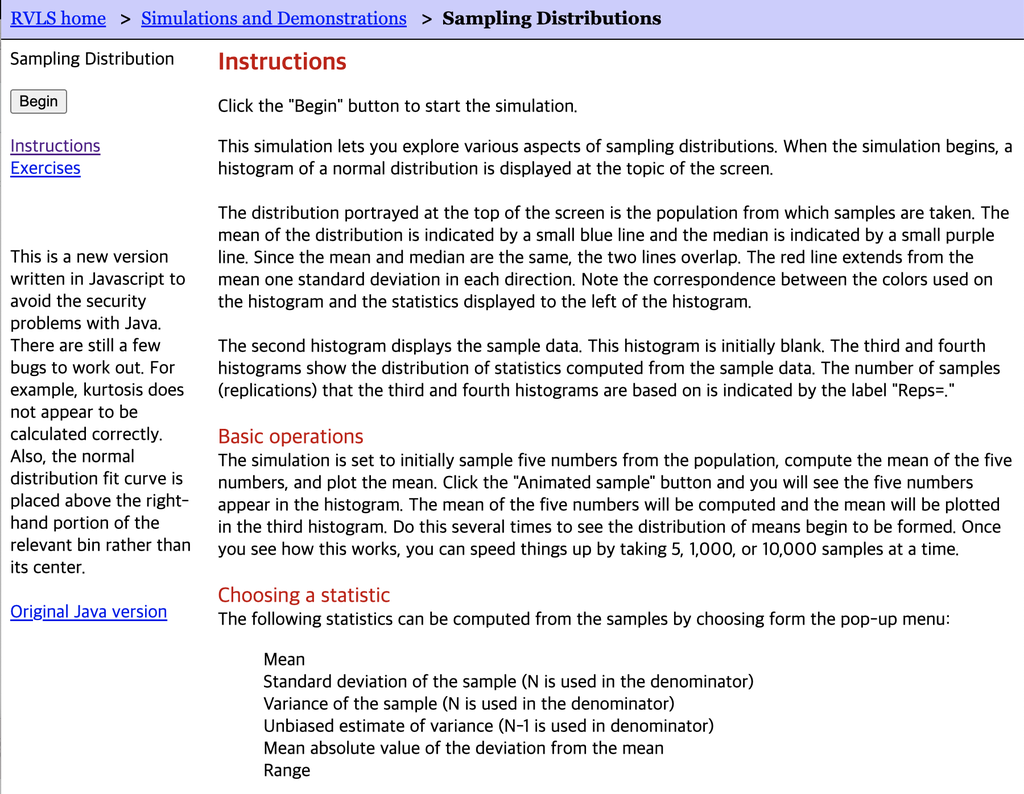

## 1.2 시뮬레이션 화면

> 시뮬레이션 설정을 동일하게 맞춥니다

> 3번째 그래프: mean, n = 2

> 4번째 그래프: Mean, n = 20

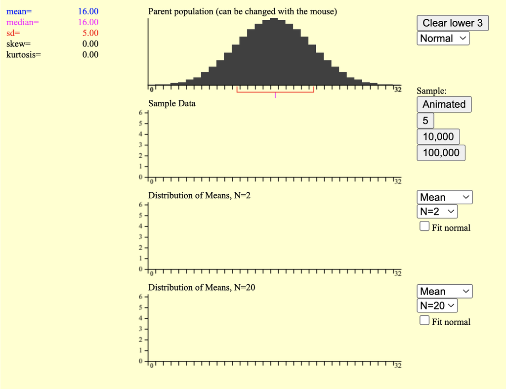

## 1.3 실행

> Animated를 클릭하고 반복하며 표본분포를 생성하고 평균과 표준편차를 확인합니다
> - 10번
> - 50번
> - 100번
> - 10,000번

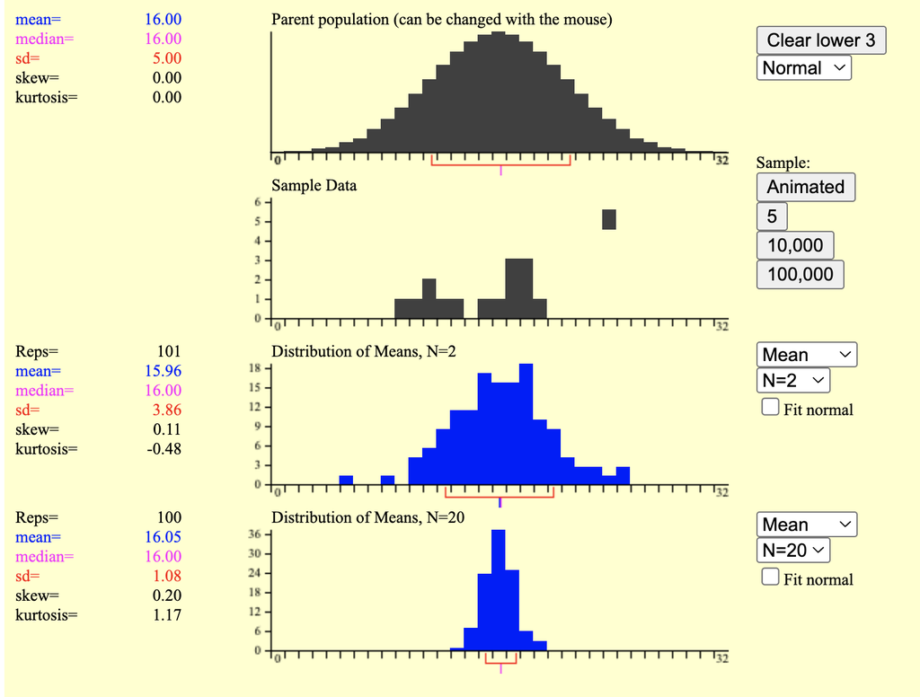

## 1.4 해석

> Reps: 반복 횟수

> mean: 평균

> median: 중앙값

> sd: 표준편차

> skew: 왜도 (분포의 좌우 비대칭 정도, 0에 가까울 수록 대칭)

> kurtosis: 첨도(중심이 뾰족하거나 좌,우 꼬리가 가는 정도)

# 2 중심극한정리

## 2.1 중심극한정리 (Central Limit Theorem)

- **한 줄 요약:** 모집단의 분포 모양과 상관없이, 표본의 크기($n$)가 충분히 크다면(보통 30 이상), **표본평균들의 분포(표본추출분포)는 무조건 정규분포(종 모양)를 따른다**는 정리입니다.
- **시뮬레이션으로 이해하기:**
  - 시뮬레이션 상단의 모집단(Parent Population) 모양을 본인이 원하는 대로 아주 이상하게(Skewed되거나 U자 모양으로) 그려봅니다.
  - 그 상태에서 표본의 크기를 $n=5$가 아니라 $n=25$나 $n=30$으로 설정하고 ‘Animated’ 또는 ‘10,000번(10k)’ 샘플링 버튼을 누릅니다.
  - 그러면 아래쪽에 그려지는 표본평균의 분포(Sampling Distribution of Mean)가 모집단의 비대칭한 모양을 전혀 닮지 않고, 예쁜 좌우 대칭의 종 모양(정규분포)으로 변하는 것을 볼 수 있습니다.

## 2.2 비대칭분포 (왜도)

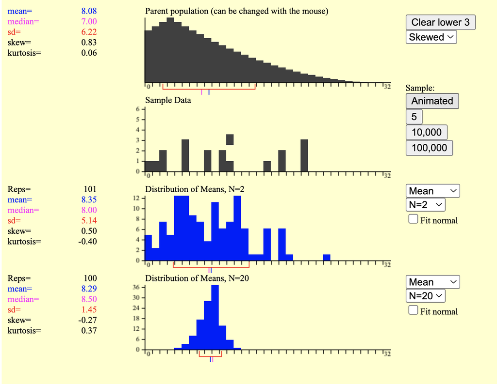

## 2.3 실행

> Animated를 클릭하고 반복하며 표본분포를 생성하고 평균과 표준편차를 확인합니다
> - 10번, 50번, 100번, 10,000번

### 2.3.1 해석

> Reps: 반복 횟수

> mean: 평균

> median: 중앙값

> sd: 표준편차

> skew: 왜도 (분포의 좌우 비대칭 정도, 0에 가까울 수록 대칭)

> kurtosis: 첨도(중심이 뾰족하거나 좌,우 꼬리가 가는 정도)

## 2.4 균일 분포 (고르게 퍼져있는 상태)

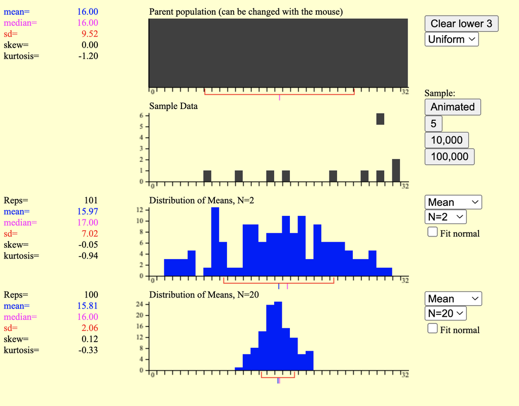

## 2.5 실행

> Animated를 클릭하고 반복하며 표본분포를 생성하고 평균과 표준편차를 확인합니다
> - 10번, 50번, 100번, 10,000번

### 2.5.1 해석

> Reps: 반복 횟수

> mean: 평균

> median: 중앙값

> sd: 표준편차

> skew: 왜도 (분포의 좌우 비대칭 정도, 0에 가까울 수록 대칭)

> kurtosis: 첨도(중심이 뾰족하거나 좌,우 꼬리가 가는 정도)

# 3 생각해볼 점

> 1. N=2로 표본을 추출할 때와 n=20으로 추출할 때 표본분포의 모양은 어떠한가요?
> 2. 표본분포가 옆으로 넓게 퍼지는 것은 어떤 시사점을 갖나요?
> 3. n=20으로 할 경우 좌,우가 대칭인 정규분포 모양을 갖는데 이것은 어떤 시사점을 갖나요?